# Multivariable Modelling of Time-Varying Effects in Survival Data Based on Fractional Polynomial Time-Transformation

2/09/2021

## Background about the article

- Article was published in the Biometrical Journal in 2007. Biometrical Journal covers statistical methods and their applications in life sciences including medicine, environmental sciences and agriculture.
- Willi Sauerbrei
  - German Statistician
  - affiliated with Institute of Medical Biometry and Medical Informatics, University Hospital of Freiburg in Freiburg, Germany.
  - Sauerbrei is the corresponding author for this paper.
- Patrick Royston
  - joined the MRC Clinical Trials Unit in 2000
  - previously a professor in the Department of Statistics and Evaluation, Imperial College, London, UK.
  - Research Areas: Cancer and Methodology
- Maxime Look
  - cancer researcher at Josephine Nefkens Institute in the Netherlands

[figure not shown]

## Abstract

- The Cox proportional hazards model is often used for analysis of survival time data in cancer.
- Proportional hazards (PH) are assumed. “With long-term follow-up, the PH assumption may be violated.”
- Goal: The authors of the paper aim to account for these non-PH effects.
  - introduces the method, MFPT, an extension of the multivariable fractional polynomial (MFP) approach
    - select influential variables.
    - determine dose-response function for continuous variables.
    - investigate time-varying effects.
    - model such time-varying effects on a continuous scale.

## Key Words

- Linear regression form:
  - \[y_i = b_0 + b_ix_i + b_2y_i+ b_2y_i^{2} + \epsilon_i\]
- \(\textbf{Fractional polynomials:}\)
  - an alternative to regular polynomials
  - provide more flexible parameterization
  - \[y_i = b_0 + b_ix_i + b_2w_i^{p_1}+ b_3w_i^{p_2} + \epsilon_i\]
  - Fractional powers, \(p_i\) are different from regular powers.
  - For instance, \(y^{p_1=0}\) is \(ln(y)\)
- \(\textbf{proportional hazards:}\)
  - exponential, Weibull, and Cox models are all proportional hazards (PH) models.
  - these models shift the hazard proportionally to the baseline
  - \[h_{A}(t) = Ch_{b}(t)\]
  - where C is the hazard ratio between B and A

## Key Words (cont.)

- \(\textbf{The semiparametric proportional hazards model of Cox (1972):}\)
  - developed by British statistician David Cox in 1972
  - popular model used in analysis of survival data
  - Goal: link the survival time of an individual to covariates
  - \[h(t) = h_0(t)+ exp(b_0 + b_1x_1 + b_2x_2+ b_3x_3 +....+ b_px_p)\]
    - t = the survival time
    - h(t) - the hazard function determined by a set of p covariates (x_1,x_2,x_3,…,x_p)
  - Key assumptions:
    - the proportional hazards function assumption
      - \(\textbf{ each covariate's multiplicative effect is constant over time.}\)

## Introduction

- Most cancer studies and other medical studies use the the Cox semi-parametric proportional hazards model for survival time data analysis
- proportional hazards (PH) are assumed for covariate effects,
  - implying that the effect on the hazard function is constant throughout the whole study.
- problem:
  - long-term follow-up studies show that the assumption of constant multiplicative effect for covariates becomes questionable.
  - Tumor size tend to strongly influence the short term prognosis
  - The effect changes over time (decreasing)

The authors in the article propose procedure called \(\textit{MFPT (multivariable fractional polynomial- time)}\):

- select influential variables
- determine dose-response functions for continuous variables
- Whether there are time-varying effects
- Better model time-varying effects

## past proposed solutions:

- the baseline cumulative hazard function.
- a step-function model
- relaxing the PH assumption and using an interaction between a covariate and time.
- fractional polynomials
- estimating local time-varying coefficients

The authors of the paper argue that it is unclear how useful these proposed methods are.

- In the article the authors perform MFPT on breast cancer data to compare differences from the previously considered methods.

## Methods

## Considerations

- Even if other variables don’t change over time they might be effected by non-PH effects
- Examining the PH assumption requires long term follow up.
- There have been solution for incorporating time-varying effects but there is no way to specify time-varying functions.
- There are many tests to check the PH assumption

## Multivariable FP:

- Cox’s suggestion for incorporating time-varyng effects
- Hazard function at time t>0 (usual assumption of proportional hazards): \[h(t|X) = h_0(t)exp[X'\beta]\]
- To build a model, the authors use the MFP algorithm (Sauerbrei and Royston, 1999)
- The algorithm uses backward elimination

It proceeds cyclically.

- functional form determined univariately
- Convergence when there are no further changes
  - this is when FP transformation takes place

## Cox’s suggestion for incorporating time-varying effects.

- Cox in 1972 proposed a way to extend his model for non-proportional hazard effects: \[h(t|X) = h_0(t)exp[X'\beta (t)]\]

Then this relative hazard becomes the function of X and t: \[\frac{h(t|X)}{h_0(t)} = exp[X'\beta]\]

For a single variable Cox proposed using an unspecified function \(\psi(t)\)

\[h(t|X) = {h_0(t)}exp[\beta_0X + \beta_1\psi(t)X]\]

Where \(\psi(t)X\) is a multiplicative interaction term that extends the orginial hazard function at time t > 0 .

\(\psi(t)X\) is hard to specify

- Different choices of \(\psi(t)X\) affect the analysis of possible time-varying effects

## \(\psi(t)\)

- The authors propose a method for estimating \(\psi(t)\) as an FP function of t

\[y_i = b_0 + b_ix_i + b_2w_i^{\psi(t)}+ b_3w_i^{\psi(t)} + \epsilon_i\]

- as a default \(\psi(t)= log(t)\)
- the authors choose a better \(\psi(t)\) if indicated by the data.
- The extension to multivariate fuction of time is done by stepwise selection

## New Proposal

## Stage 1

select model \(M_0\) using MFP algorithm using PH

\(M_0\) is the model intially selected by \(MFP\) , with time-fixed effects only.

the effect of at least one variable of interest varies in time, model M0 either mismodels its relative hazard as constant in time

- PH assumption the estimated ‘average’ effect over the full time period could be small.
- more intial important variables could strongly increase the risk of an event near the beginning but then diminish over time.
- check whether the variables is not included in \(M_0\) is transient or short term effect.

## Stage 2

1.) Start with the model \(M_0\)

censor all events when one half of all events have been observed. This is the defintion of short-term.

2.) restrict the time period to \((0,\hat t)\) where \(\hat t\) is the first half of events

3.) re-apply MFP

- allow for variables not selected in full time period
- Variables and FP selected in stage 1
  - regression coefficients are re-estimated
  - The FP functions (powers) kept fixed when studying time-varying effects.

This gives \(M_1\)

## FPT:

extend Cox’s basic approach for modelling a time-varying effect of a given covariate \(X\)

An FP1 function (or model) is defined as \[\psi_1(x;p) = \beta_0 + \beta_1x^p\]

FP2 transformation of x with \(p = (p_1,p_2)\) is the vector \(x^p\) with

\[x^p = x ^{(p_1,p_2)} = \bigg\{(x^{p_1},x^{p_2}) \ p_1 \neq p_2 \ \\ \ \ (x^{p_1},x^{p_2}, logx) \ p_1 = p_2= p\]

\(\beta = (\beta_1, \beta_2)\) and powers \(p\) \[\psi_2(x;p) = \beta_0 + x^p\beta\]

time-varying Cox model based on untransformed X and an FP2 function of t with powers P = (q_1;q_2):

\[h(t|X) =h_0(t)exp[X_{\psi_2}(t; q)] =\]

\[= {h_0(t)}exp[X(\beta_0 + \beta_1t^{q_1}+\beta_2t^{q_2})] \, where \ q_1 \neq q_2 \] \[= {h_0(t)}exp[X(\beta_0 + \beta_1t^{q_1}+\beta_2t^{q_2}log(t))] \, where\ q_1 = q_2 \]

compare deviance difference of the models \(\psi_j(t)\) and \(\psi_k(t)\) where \(j < k\) with \(\chi_c^2\) valvues \(c= df\)

for example the deviance difference between \(\psi_1(t)\) and \(\psi_2(t)\) is compared with \(\chi_2^2\).

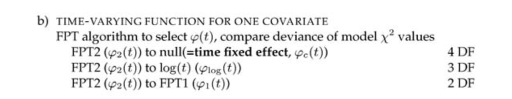

If this test is significant, the more complex FP2 function \(\psi_2(t)\) is chosen, otherwise the simpler FP1 function \(\psi_1(t)\)

## Stage 3:

1. For each covariate with the slected FP of \(M_1\) run the FPT algorithm.

check for time varying effects.

1. Use foward selection to select variables that give significant time varying effects to \(M_1\).
2. new model is \(M_2\).

## data

## Cases

- 3001 patients from the Rotterdam breast cancer series:
- primary breast cancer treatment 1973-1993
- excluding cases with missing information, \(n = 2982\) for analysis.
  - missing information about the number of positive nodes (n = 11)
  - adjuvant treatment of node negative patients (n = 8)

## Variables

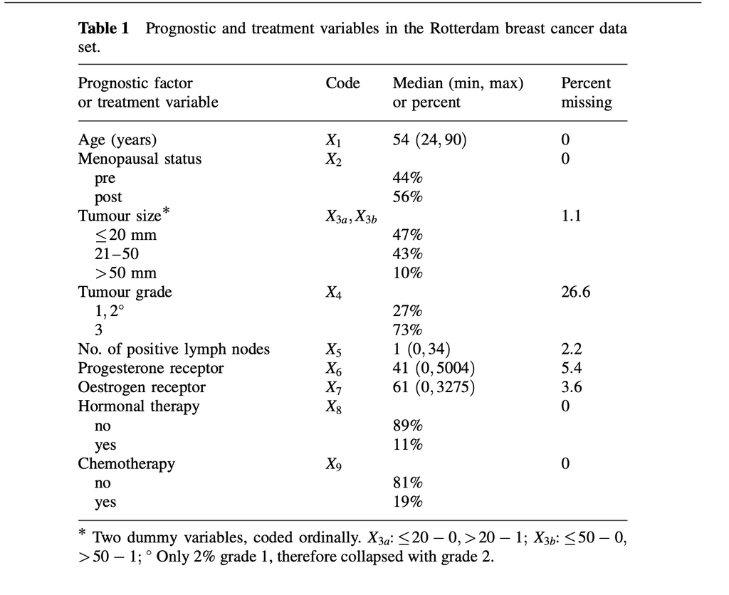

## missing data:

- The variable Tumor grade was missing for 27% of the data.
- The authors use MICE method of multivariate multiple imputation to account the missing values.
- Missing data imputation is the idea subsituting data for missing values.
- Multiple imputation takes into account uncertainty in missing value imputation.
- The authors use the Stata program mvis (Royston, 2004)
- We can do this in r with the mice package and the function mice()

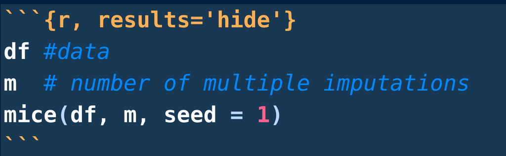

## Results

## Time-varying effects in final model

Regression parameter estimates are given in Table 4.

- Estimates of parameters of models
  - M0 (stage 1)
  - M1 (stage 2)
  - M2 (stage 3).

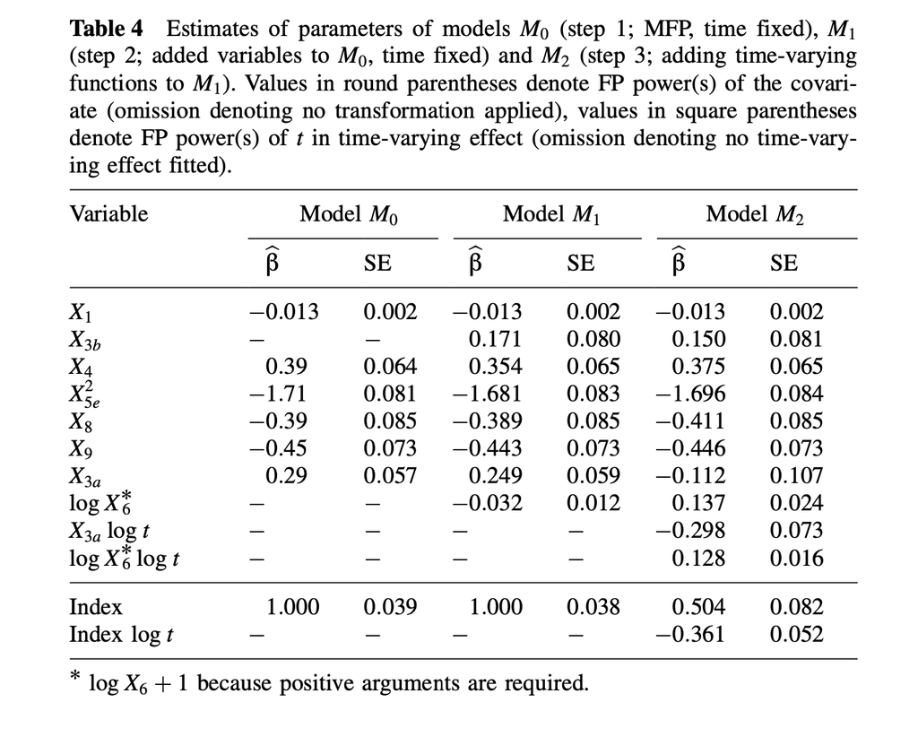

- These two variables, \(X_3b\) and \(X6\) are added to the variables in \(M_0\) gives model \(M_1\).

## result of model

- The MFPT algorithm to extend Cox model M1 with time-varying functions.
- For each variable powers of the best FP1 and FP2 functions

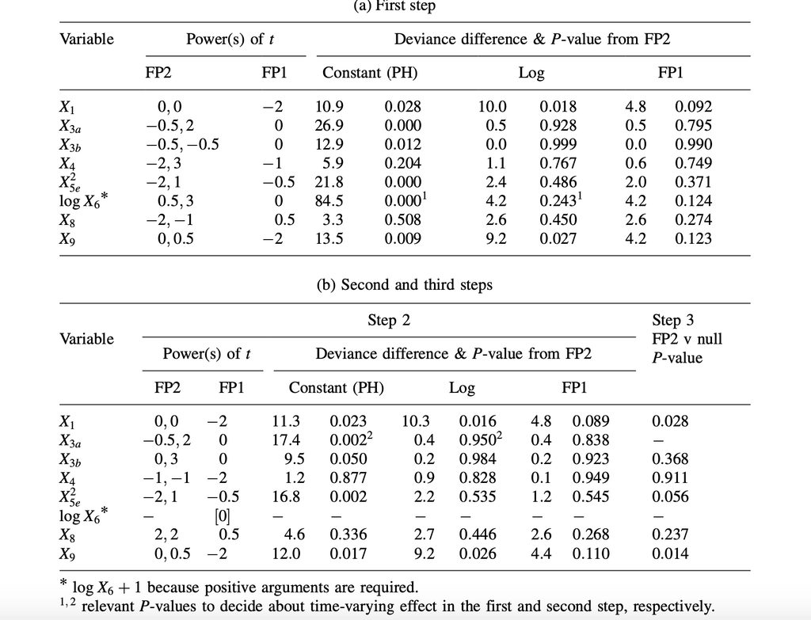

- P-values of tests to assess a time-varying effect.
- log X6 and log X3a at the second step.

## Time-varying effects in final model

- the two variables \(X3a\) and \(log X6\) .

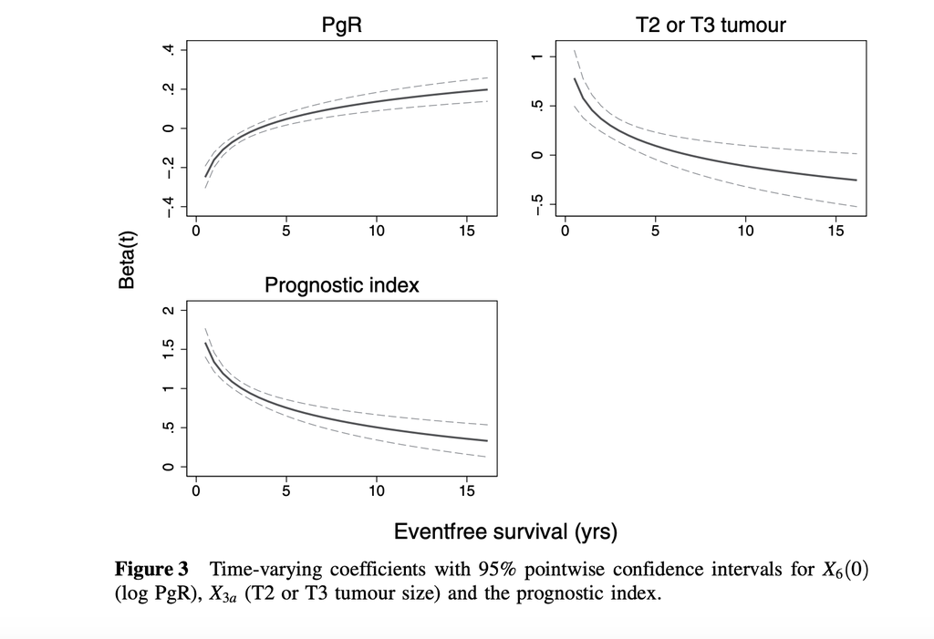

- the effect of the prognostic index diminishes in time.

## Sensitivity Analysis MFPT model

- Backwards elimination and foward selection.
- stage 3 of the MFPT algorithm for model M1

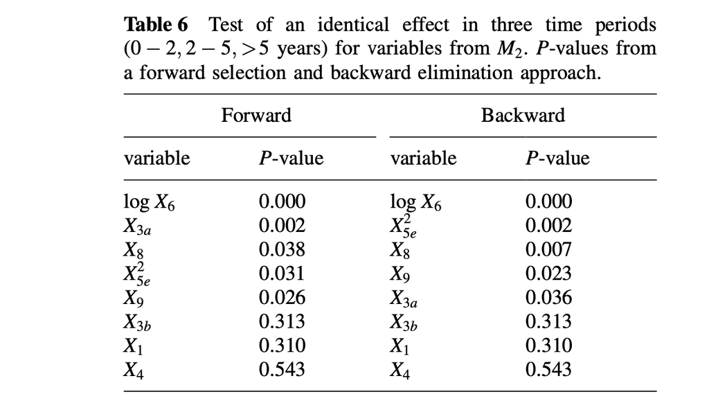

- at 5% significance level both selction methods give the same model.

## Type I error

- check type I error probability of FTP for a single binary covariate.

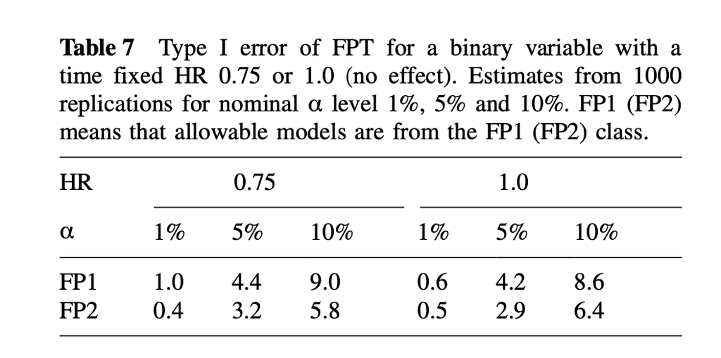

- X assigned to a time fixed hazard ratio of either 0.75 or 1.0
- 1000 simulations distributed time to event data without censoring.
  - count the number of times we reject null hypothesis with no time varying effect.

## conclusion

- Time-varying issues are more important for long term follow ups.
- MFPT procedure handles the key stages of a model-building procedure for such problems.
- MFPT is flexible enough to incorporate information.
- Further investigatons into: type I and type II error at all 3 stages.